# Take-home interview for Stonehenge Tech Labs: Determining key insights and building a minimalistic recommender system from a beer review dataset

### Given a dataset with approximately 1.6 million reviews, I aim to give a general overview of my data science and data manipulation abilities by answering the following questions:

1. Which brewery produces the strongest beers by ABV%?
2. If you had to pick 3 beers to recommend using only this data, which would you pick?
3. Which of the factors (aroma, taste, appearance, palette) are most important in determining the overall quality of a beer?
4. If I typically enjoy a beer due to its aroma and appearance, which beer style should I try?

### Detail out anything else you think is interesting about the data.

### Imports

```python
import pandas as pd
import numpy as np
import matplotlib.pyplot as plt
import seaborn as sns
from math import pi
```

### Functions

```python
# bayes_weighted_rating: calculates a bayes estimate weighted rating
#   based on an equation documented below (Question #2)
def bayes_weighted_rating(df, this_col, m, C):
    v = df['counts']
    R = df[this_col]
    return ((v/(v+m)*R) + (m/(m+v)*C))
```

```python
# new_review_overall: creates a new overall review score taking into
#   consideration all review categories which are weighted according
#   to their pearson correlation with review_overall
def new_review_overall(df, review_cols, corr):
    new_review = 0
    for col in review_cols:
        new_review = new_review + df[col]*corr[col]
    return new_review/sum(corr)
```

### Visual Settings

```python
my_colors = plt.cm.get_cmap("Set2", 4)
div_cmap = sns.diverging_palette(144, 270, s=87, l=50, n=9, as_cmap = True)
plt.style.use('seaborn-darkgrid')
```

### Reading in the Data

```python
file = '../data/beer_reviews.csv'
df = pd.read_csv(file)
```

## Data Exploration and Cleaning

Before diving too deeply into analyzing a dataset it is a good idea to get a feel for your dataset to appropriately choose which methodologies to implement and how to approach data cleaning. Note, I'll only use my cleaned dataset for questions 2-4 and do the cleaning on a case-by-case basis for question 1.

```python
df.info()
```

```
<class 'pandas.core.frame.DataFrame'>
RangeIndex: 1586614 entries, 0 to 1586613
Data columns (total 13 columns):
 #   Column              Non-Null Count    Dtype
---  ------              --------------    -----
 0   brewery_id          1586614 non-null  int64
 1   brewery_name        1586599 non-null  object
 2   review_time         1586614 non-null  int64
 3   review_overall      1586614 non-null  float64
 4   review_aroma        1586614 non-null  float64
 5   review_appearance   1586614 non-null  float64
 6   review_profilename  1586266 non-null  object
 7   beer_style          1586614 non-null  object
 8   review_palate       1586614 non-null  float64
 9   review_taste        1586614 non-null  float64
 10  beer_name           1586614 non-null  object
 11  beer_abv            1518829 non-null  float64
 12  beer_beerid         1586614 non-null  int64
dtypes: float64(6), int64(3), object(4)
memory usage: 157.4+ MB
```

```python
df.describe().transpose()
```

|  | count | mean | std | min | 25% | 50% | 75% | max |
| --- | --- | --- | --- | --- | --- | --- | --- | --- |
| brewery_id | 1586614.0 | 3.130099e+03 | 5.578104e+03 | 1.000000e+00 | 1.430000e+02 | 4.290000e+02 | 2.372000e+03 | 2.800300e+04 |
| review_time | 1586614.0 | 1.224089e+09 | 7.654427e+07 | 8.406720e+08 | 1.173224e+09 | 1.239203e+09 | 1.288568e+09 | 1.326285e+09 |
| review_overall | 1586614.0 | 3.815581e+00 | 7.206219e-01 | 0.000000e+00 | 3.500000e+00 | 4.000000e+00 | 4.500000e+00 | 5.000000e+00 |
| review_aroma | 1586614.0 | 3.735636e+00 | 6.976167e-01 | 1.000000e+00 | 3.500000e+00 | 4.000000e+00 | 4.000000e+00 | 5.000000e+00 |
| review_appearance | 1586614.0 | 3.841642e+00 | 6.160928e-01 | 0.000000e+00 | 3.500000e+00 | 4.000000e+00 | 4.000000e+00 | 5.000000e+00 |
| review_palate | 1586614.0 | 3.743701e+00 | 6.822184e-01 | 1.000000e+00 | 3.500000e+00 | 4.000000e+00 | 4.000000e+00 | 5.000000e+00 |
| review_taste | 1586614.0 | 3.792860e+00 | 7.319696e-01 | 1.000000e+00 | 3.500000e+00 | 4.000000e+00 | 4.500000e+00 | 5.000000e+00 |
| beer_abv | 1518829.0 | 7.042387e+00 | 2.322526e+00 | 1.000000e-02 | 5.200000e+00 | 6.500000e+00 | 8.500000e+00 | 5.770000e+01 |
| beer_beerid | 1586614.0 | 2.171279e+04 | 2.181834e+04 | 3.000000e+00 | 1.717000e+03 | 1.390600e+04 | 3.944100e+04 | 7.731700e+04 |

```python
len(df.beer_beerid.unique()) # how many distict beers are there?
```

```
66055
```

```python
len(df.brewery_id.unique()) # how many breweries are represented?
```

```
5840
```

```python
len(df.review_profilename.unique()) # how many reviewers are there?
```

```
33388
```

Here I want to compare the mean and median number of reviews a specific user has.

```python
# median reviews a user gives
df.groupby('review_profilename', as_index = True)['beer_beerid']\
  .count()\
  .median()
```

```
3.0
```

```python
# mean reviews a user gives
df.groupby('review_profilename', as_index = True)['beer_beerid']\
  .count()\
  .mean()
```

```
47.511486506724175
```

Quite a right skew with a median of 3 but a mean around 47.5! Now I do similar but I compare the mean and the median number of reviews a specific beer gets.

```python
# median reviews a user gives
df.groupby('beer_beerid', as_index = True)['review_overall']\
  .count()\
  .median()
```

```
2.0
```

```python
# mean reviews a user gives
df.groupby('beer_beerid', as_index = True)['review_overall']\
  .count()\
  .mean()
```

```
24.019589735826205
```

Similarly very right-skewed. In my opinion, this is expected. While I'm not backing this up with data, my intuition says your average reviewer likely only posts if they are incredibly impressed or unimpressed with a beer. While insights from beers and users with a low number of reviews may be valuable in a more fleshed out recommendation system, for this project I'll drop them.

```python
# calling my filtered/cleaned dataset "reviews", "df" will be my raw
reviews = df[df['beer_beerid'].map(df['beer_beerid'].value_counts()) > 25]
```

```python
reviews = reviews[reviews['review_profilename'].map(df['review_profilename'].value_counts()) > 48]
```

Now let's check how various features are correlated using the Python package seaborn. Before doing this, I also change 'review_time' to a DateTime object.

```python
# change review_time from UNIX POSIX to datetime object
reviews['review_time'] = pd.to_datetime(reviews['review_time'], unit = 's')
```

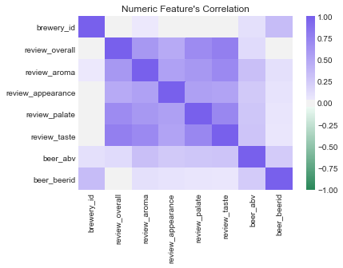

```python
numeric_cols = reviews.select_dtypes(include=['int64', 'float64']).columns

sns.heatmap(reviews[numeric_cols].corr(), vmin = -1, vmax = 1, center = 0, cmap=div_cmap)
plt.title('Numeric Feature\'s Correlation')
```

Notice taste has the strongest correlation with overall review, followed by palate, aroma, and finally, appearance.

At this point, let's see what sort of data imputation we need to do.

```python
reviews.isnull().sum()
```

```
brewery_id                0
brewery_name              0
review_time               0
review_overall            0
review_aroma              0
review_appearance         0
review_profilename        0
beer_style                0
review_palate             0
review_taste              0
beer_name                 0
beer_abv              16827
beer_beerid               0
dtype: int64
```

After dropping rarely rated beers and inactive users, all we have to impute is 'beer_abv'. After some exploration, I determined to use 'beer_style's mean 'beer_abv' to impute into missing values.

```python
reviews.beer_abv = reviews.groupby('beer_style')['beer_abv'].apply(lambda x: x.fillna(x.mean()))
```

```python
# if you want to explore the data a bit...

# for col in df.columns:
#     tmp = df.groupby(col).beer_abv.transform('mean')
#     rse = np.sqrt((tmp - df.beer_abv)**2)
#     rmse = rse.mean()
#     print(col)
#     print(np.std(tmp))
#     print(rmse)
```

```python
# i wanted to view the data more as a time series...
reviews = reviews.sort_values('review_time', ascending=False)
```

```python
# dropping duplicates if present
reviews = reviews.drop_duplicates(subset= ['review_profilename','beer_name', 'brewery_name'], keep='first')
```

Now let's check out our cleaned dataset.

```python
reviews.describe().transpose()
```

|  | count | mean | std | min | 25% | 50% | 75% | max |
| --- | --- | --- | --- | --- | --- | --- | --- | --- |
| brewery_id | 1175246.0 | 2588.336452 | 5009.348450 | 1.0 | 140.0 | 363.0 | 1534.0 | 27681.0 |
| review_overall | 1175246.0 | 3.829630 | 0.694019 | 1.0 | 3.5 | 4.0 | 4.5 | 5.0 |
| review_aroma | 1175246.0 | 3.760654 | 0.672908 | 1.0 | 3.5 | 4.0 | 4.0 | 5.0 |
| review_appearance | 1175246.0 | 3.860878 | 0.598254 | 1.0 | 3.5 | 4.0 | 4.0 | 5.0 |
| review_palate | 1175246.0 | 3.766262 | 0.658550 | 1.0 | 3.5 | 4.0 | 4.0 | 5.0 |
| review_taste | 1175246.0 | 3.811445 | 0.701609 | 1.0 | 3.5 | 4.0 | 4.5 | 5.0 |
| beer_abv | 1175246.0 | 7.125685 | 2.316692 | 0.3 | 5.3 | 6.5 | 8.5 | 41.0 |
| beer_beerid | 1175246.0 | 19563.531162 | 20796.208240 | 5.0 | 1490.0 | 9086.0 | 36468.0 | 76816.0 |

## 1. Which brewery produces the strongest beers by ABV%?

Below I have the printed the top beers by abv, the breweries with the top beers by abv, then finally the breweries with the top mean and median beer by abv. Note for this section I use my raw dataset as I am interested in the most "extreme" beers regardless of the number of reviews they have.

```python
### Beers with highest ABV
beer_highest_abv = df[['beer_name', 'beer_abv']]\
                        .drop_duplicates('beer_name')\
                        .sort_values('beer_abv', ascending = False)

print('Beer with highest ABV:')
print(beer_highest_abv.head(10))
```

```
Beer with highest ABV:
                             beer_name  beer_abv
12919    Schorschbräu Schorschbock 57%     57.70
12939    Schorschbräu Schorschbock 43%     43.00
746310              Sink The Bismarck!     41.00
12934    Schorschbräu Schorschbock 40%     39.44
996149      Black Damnation VI - Messy     39.00
748332        Tactical Nuclear Penguin     32.00
12918    Schorschbräu Schorschbock 31%     30.86
1042320                           Dave     29.00
746420                      Ghost Deer     28.00
293578            Samuel Adams Utopias     27.00
```

```python
### Highest ABV from brewery with strongest beers
brewery_highest_abv = df.sort_values('beer_abv', ascending = False)[['brewery_name', 'beer_abv']]\
                        .drop_duplicates('brewery_name')
print('Highest ABV from brewery with strongest beers:')
print(brewery_highest_abv.head(10))
```

```
Highest ABV from brewery with strongest beers:
                                              brewery_name  beer_abv
12919                                         Schorschbräu     57.70
746385                                             BrewDog     41.00
996153                                 De Struise Brouwers     39.00
1042328  Hair of the Dog Brewing Company / Brewery and ...     29.00
293821                  Boston Beer Company (Samuel Adams)     27.00
569500                           LagerHaus Grill & Brewery     22.00
1386396                             DuClaw Brewing Company     21.92
1199891                            Short's Brewing Company     20.00
1375146                         Grand Lake Brewing Company     20.00
667534                             Sonoran Brewing Company     19.50
```

```python
### Aggregate the data with counts for unique beer/brewery entries, mean abv, median abv
brewery_abv = df[df.beer_abv.notna()][['beer_name','brewery_name','beer_abv']]\
                    .drop_duplicates(['beer_name', 'brewery_name'])\
                    .groupby('brewery_name', as_index = False)[['beer_abv', 'beer_name']]\
                    .agg({'beer_name': 'count', 'beer_abv': ['median', 'mean']})

brewery_abv.columns = brewery_abv.columns.to_series().str.join('_')
brewery_abv.rename(columns = {'brewery_name_' : 'brewery_name'}, inplace = True)
```

```python
# let's only use breweries with more unique beers than 50% of breweries
brewery_abv.describe().transpose()
```

|  | count | mean | std | min | 25% | 50% | 75% | max |
| --- | --- | --- | --- | --- | --- | --- | --- | --- |
| beer_name_count | 5155.0 | 9.467507 | 17.361097 | 1.0 | 2.000 | 4.000000 | 10.0 | 522.00 |
| beer_abv_median | 5155.0 | 5.651426 | 1.217984 | 0.5 | 4.900 | 5.350000 | 6.2 | 16.00 |
| beer_abv_mean | 5155.0 | 5.798452 | 1.253577 | 0.5 | 4.975 | 5.566667 | 6.5 | 24.69 |

```python
### Brewery with highest mean ABV (discluding breweries with < 4 beers)
brewery_mean_abv = brewery_abv[brewery_abv['beer_name_count'] >= 4][['brewery_name', 'beer_abv_mean']]\
                          .sort_values('beer_abv_mean', ascending = False)
print('Brewery with strongest beers on average:')
print(brewery_mean_abv.head(10))
```

```
Brewery with strongest beers on average:
                         brewery_name  beer_abv_mean
4207                     Schorschbräu      24.690000
755   Brasserie Dubuisson Frères sprl      10.607143
1158      Brouwerij De Dolle Brouwers      10.257143
89           AleSmith Brewing Company      10.165769
1731              De Struise Brouwers      10.130435
4249          Sherbrooke Liquor Store      10.000000
3655          Pacific Rim Brewing Co.       9.825000
1190        Brouwerij Het Alternatief       9.750000
1883          Element Brewing Company       9.675000
164              Arctic Craft Brewery       9.666667
```

```python
### Brewery with highest median ABV (discluding breweries with < 4 beers)
brewery_median_abv = brewery_abv[brewery_abv['beer_name_count'] >= 4][['brewery_name', 'beer_abv_median']]\
                          .sort_values('beer_abv_median', ascending = False)
print('Brewery with strongest median beers:\n')
print(brewery_median_abv.head(10))
```

```
Brewery with strongest median beers:

                                           brewery_name  beer_abv_median
4207                                       Schorschbräu            16.00
755                     Brasserie Dubuisson Frères sprl            11.25
89                             AleSmith Brewing Company            11.00
1158                        Brouwerij De Dolle Brouwers            10.50
1731                                De Struise Brouwers            10.00
2312  Hair of the Dog Brewing Company / Brewery and ...            10.00
4826                      Two Rows Restaurant & Brewery             9.80
1190                          Brouwerij Het Alternatief             9.50
1994                             FiftyFifty Brewing Co.             9.50
1170                                 Brouwerij De Molen             9.20
```

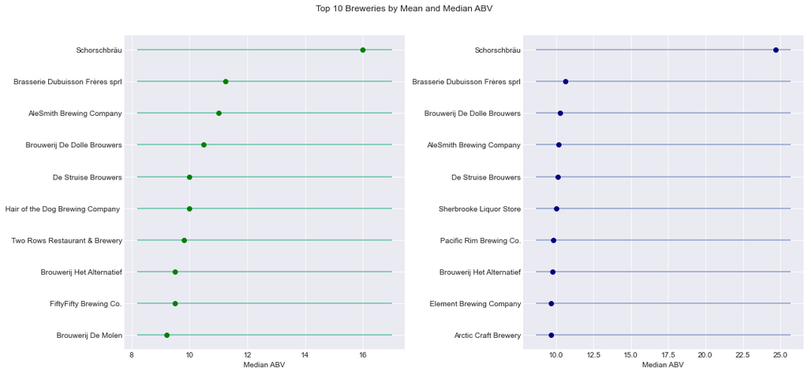

```python
x0 = brewery_median_abv.beer_abv_median.head(10).iloc[::-1]
y0 = brewery_median_abv.brewery_name.head(10).iloc[::-1].tolist()
y0[4] = y0[4].split('/')[0] #long gross name fix

x1 = brewery_mean_abv.beer_abv_mean.head(10).iloc[::-1]
y1 = brewery_mean_abv.brewery_name.head(10).iloc[::-1].tolist()

fig, axes = plt.subplots(nrows=1, ncols=2, figsize = (15,7))

my_range = range(1,11)

# --- plot 1
axes[0].hlines(y=my_range, xmin=min(x0)-1, xmax=max(x0)+1, color=my_colors(0))
axes[0].plot(x0, my_range, 'o', color='g')

# titles and axis names
axes[0].set_yticks(my_range)
axes[0].set_yticklabels(y0)
axes[0].set_xlabel('Median ABV')

# --- plot 2
axes[1].hlines(y=my_range, xmin=min(x1)-1, xmax=max(x1)+1, color=my_colors(1))
axes[1].plot(x1, my_range, 'o', color='navy')

# titles and axis names
axes[1].set_yticks(my_range)
axes[1].set_yticklabels(y1)
axes[1].set_xlabel('Median ABV')


# --- final plot
fig.tight_layout()
plt.subplots_adjust(top=0.9)
fig.suptitle("Top 10 Breweries by Mean and Median ABV")

plt.show()
```

#### Answer #1 Overall, Schorschbräu is consistently the brewery with the strongest beers - whether considering the absolute strongest beer, strongest average beer, or strongest median beer.

## 2. If you had to pick 3 beers to recommend using only this data, which would you pick?

For this, I'm going to recommend 3 "Top Beers". These beers are topping the charts, but likely not niche enough for your craft beer aficionado to be impressed. To achieve this, I decided to go with a weighted rating system utilizing a Bayes Estimator (like that used by IMDB movie ratings). Our weighted rating will be calculated with the following equation:

WR = (v*R)/(v+m) + (m*C)/(v+m)

WR: weighted rating  
v: number of votes  
m: minimum votes required to be listed  
R: average rating of the beer as a number from 1 to 5  
C: mean vote across the dataset

More info [here](https://www.fxsolver.com/browse/formulas/Bayes+estimator+-+Internet+Movie+Database+%28IMDB%29)

```python
reviews.groupby('beer_beerid', as_index = True)['review_overall']\
  .count().describe().transpose()
```

```
count    7848.000000
mean      149.751019
std       225.746173
min        14.000000
25%        37.000000
50%        66.000000
75%       157.000000
max      2319.000000
Name: review_overall, dtype: float64
```

I'm going to use a somewhat low standard and set 'm' to be the 75% percentile

```python
m = 157
```

Additionally, rather than simply use the review_overall, I'm going to create a new "overall" rating which uses the Pearson Correlation to weight each section. We'll specifically use the following equation:

new_rating = sum(corr_i*r_i)/sum(corr_i) for all i

corr_i: correlation between rating overall and rating category 'i' r_i: rating for rating category 'i'

The value of this is in part because the overall is incredibly discrete rather than continuous - you must give your beer an overall rating between 1 and 5 at 0.5 increments. Implementing this, I hope to differentiate between users giving "high" 4.5 overall ratings and "low" 4.5 ratings (and similar).

```python
# lets see our pearson correlation for different categories
review_cols = [col for col in df.columns if 'review' in col]
review_cols = [col for col in review_cols if ('time' not in col and 'profilename' not in col)]

review_overall_corr = reviews[review_cols].corr()['review_overall']
review_overall_corr
```

```
review_overall       1.000000
review_aroma         0.602506
review_appearance    0.482996
review_palate        0.689357
review_taste         0.777794
Name: review_overall, dtype: float64
```

First, let's aggregate our data so we aren't applying to every individual review, but rather the means for each beer in each category

```python
# get the number of reviews for a beer and the mean rating
grp = reviews.groupby(['beer_beerid', 'beer_name', 'brewery_name'])
agg_reviews = grp.size().to_frame(name='counts')
agg_reviews = (agg_reviews
                .join(grp.agg({'review_overall': 'mean'}))
                .join(grp.agg({'review_aroma': 'mean'}))
                .join(grp.agg({'review_appearance': 'mean'}))
                .join(grp.agg({'review_palate': 'mean'}))
                .join(grp.agg({'review_taste': 'mean'}))
                .reset_index()
              )

# get the (average) new_review_overall for each beer
agg_reviews['new_review_overall'] = agg_reviews\
                                     .apply(new_review_overall, args = (review_cols, review_overall_corr), axis=1)

# add for analysis later
review_cols.append('new_review_overall')
# out of curiosity, lets check the absolute top beers thus far...
agg_reviews.sort_values('new_review_overall', ascending = False).head(5)
```

|  | beer_beerid | beer_name | brewery_name | counts | review_overall | review_aroma | review_appearance | review_palate | review_taste | new_review_overall |
| --- | --- | --- | --- | --- | --- | --- | --- | --- | --- | --- |
| 3819 | 24273 | M Belgian-Style Barleywine | Midnight Sun Brewing Co. | 24 | 4.833333 | 4.812500 | 4.479167 | 4.854167 | 4.916667 | 4.803937 |
| 7384 | 63649 | Rare D.O.S. | Peg's Cantina & Brewpub / Cycle Brewing | 24 | 4.854167 | 4.770833 | 4.458333 | 4.812500 | 4.875000 | 4.782695 |
| 7648 | 68548 | Armand'4 Oude Geuze Lente (Spring) | Brouwerij Drie Fonteinen | 57 | 4.719298 | 4.710526 | 4.500000 | 4.657895 | 4.710526 | 4.674161 |
| 5715 | 44910 | Dirty Horse | De Struise Brouwers | 32 | 4.812500 | 4.609375 | 4.406250 | 4.593750 | 4.750000 | 4.666691 |
| 3646 | 21690 | Pliny The Younger | Russian River Brewing Company | 454 | 4.574890 | 4.707048 | 4.443833 | 4.585903 | 4.698238 | 4.608627 |

```python
# C should be the average rating of ALL beers, not only the top 75%
C = agg_reviews['new_review_overall'].mean()
mean_review = agg_reviews.mean()
print('The average rating of all beers is: ', np.round(C, 2))

# now we want only the top 75% by number of ratings
agg_reviews = agg_reviews[agg_reviews['counts'] > m]
this_col = 'new_review_overall'
agg_reviews['review_weighted'] = agg_reviews.apply(bayes_weighted_rating, args = (this_col, m, C), axis=1)
agg_reviews = agg_reviews.sort_values('review_weighted', ascending = False)
```

```
The average rating of all beers is:  3.7
```

```python
agg_reviews.head(3)
```

|  | beer_beerid | beer_name | brewery_name | counts | review_overall | review_aroma | review_appearance | review_palate | review_taste | new_review_overall | review_weighted |
| --- | --- | --- | --- | --- | --- | --- | --- | --- | --- | --- | --- |
| 835 | 1545 | Trappist Westvleteren 12 | Brouwerij Westvleteren (Sint-Sixtusabdij van W... | 1026 | 4.593080 | 4.567251 | 4.420565 | 4.613548 | 4.700292 | 4.592690 | 4.474132 |
| 2519 | 7971 | Pliny The Elder | Russian River Brewing Company | 1669 | 4.573996 | 4.596465 | 4.366687 | 4.427801 | 4.608149 | 4.528732 | 4.457421 |
| 3469 | 19960 | Founders KBS (Kentucky Breakfast Stout) | Founders Brewing Company | 1419 | 4.384778 | 4.559901 | 4.341790 | 4.480268 | 4.619098 | 4.478463 | 4.400848 |

Now, I'll make a spider/radar plot so we can visualize how our top beers perform is various categories

```python
# Let's plot out how these beers compare to the "average"
mean_review['review_weighted'] = mean_review['new_review_overall']

top_beers = agg_reviews.head(3)
top_beers = top_beers.append(mean_review, ignore_index = True)
```

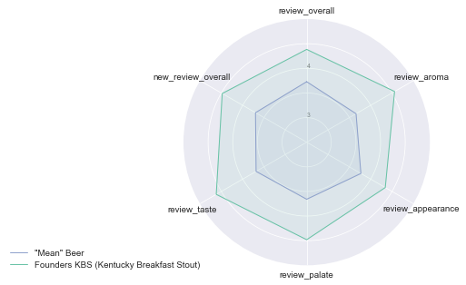

```python
### following rader graph method from python-graph-gallery

## --- create background

# number of variables
N = len(review_cols)

# angle of each axis determined by dividing plot / number of variable
angles = [n / float(N) * 2 * pi for n in range(N)]
angles += angles[:1]

# initialise the radar graph
plt.figure(figsize=(5,7), dpi= 70, facecolor='w', edgecolor='k')
ax = plt.subplot(111, polar=True)

# set the first axis to be on top:
ax.set_theta_offset(pi / 2)
ax.set_theta_direction(-1)

# draw one axe per variable + add labels labels yet
plt.xticks(angles[:-1], review_cols)

# draw ylabels
ax.set_rlabel_position(0)
plt.yticks([3, 3.5,4, 4.5], ["3", "", "4", ""], color="grey", size=7)
plt.ylim(2.5,5)

## --- add plots

## Mean Beer

values=top_beers.loc[3][review_cols].values.flatten().tolist()
values += values[:1]
ax.plot(angles, values, color = my_colors(1), linewidth=1, linestyle='solid', label="\"Mean\" Beer")
ax.fill(angles, values, color = my_colors(1), alpha=0.1)

## Top Beer

# change this number to whichever top beer (1:3) you want to graph
rank = 3

rank -= 1
values=top_beers.loc[rank][review_cols].values.flatten().tolist()
values += values[:1]
title = top_beers.loc[rank]['beer_name']
ax.plot(angles, values, color = my_colors(0), linewidth=1, linestyle='solid', label=title)
ax.fill(angles, values, color = my_colors(0), alpha=0.1)

## Add legend
plt.legend(loc='upper right', bbox_to_anchor=(0.1, 0.1))
```

```python
review_cols = review_cols[:-1] #remove the "new_review_overall", cleanup for next section
```

#### Answer #2: My top recommendations are (1) Trappist Westvleteren 12 from Brouwerij Westvleteren (2) Pliny The Elder from Russian River Brewing Company and (3) Founders KBS (Kentucky Breakfast Stout) from Founders Brewing Company

An interesting extension would be to explore personalized recommendations (recommendation system) using something like matrix factorization. Another clear option would be to utilize the DateTime to try identifying "trending" or "viral" beers.

## 3. Which of the factors (aroma, taste, appearance, palette) are most important in determining the overall quality of a beer?

While answered in "data exploration" and beyond, but I'll spend a bit more time summarizing and visualizing my findings.

```python
review_cats = reviews[review_cols]
review_cats.columns = review_cats.columns.to_series().str.lstrip('review_').apply(lambda x: x.capitalize())
```

One way to determine the importance is by the Pearson Correlation

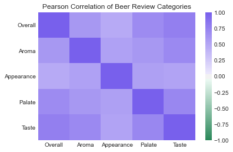

```python
pearson_corr = review_cats.corr() # pearson is the default
sns.heatmap(pearson_corr, vmin = -1, vmax = 1, center = 0, cmap=div_cmap)
plt.title('Pearson Correlation of Beer Review Categories')
```

Alternatively, if you were worried about your data not being normally distributed or not being linearly related, you could use the Spearman or Kendall method. While it's certainly plausible our reviews aren't normally distributed, it should be reasonably safe to use the Pearson correlation.

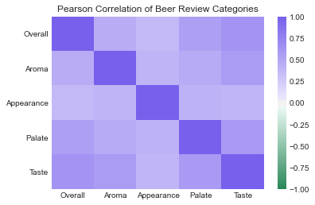

```python
kendall_corr = review_cats.corr(method = 'kendall')
sns.heatmap(kendall_corr, vmin = -1, vmax = 1, center = 0, cmap=div_cmap)
plt.title('Pearson Correlation of Beer Review Categories')
```

Spearman correlation implies your data is monotonic (data is increasing or decreasing in the same direction) but not necessarily at the same rate (e.g. linear)

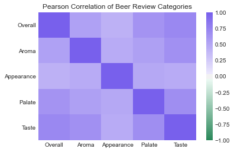

```python
spearman_corr = review_cats.corr(method = 'spearman')
sns.heatmap(spearman_corr, vmin = -1, vmax = 1, center = 0, cmap=div_cmap)
plt.title('Pearson Correlation of Beer Review Categories')
```

```python
pd.concat([spearman_corr['Overall'].rename('Spearman'),
           kendall_corr['Overall'].rename('Kendall'),
           pearson_corr['Overall'].rename('Pearson')], axis = 1)
```

|  | Spearman | Kendall | Pearson |
| --- | --- | --- | --- |
| Overall | 1.000000 | 1.000000 | 1.000000 |
| Aroma | 0.543660 | 0.466756 | 0.602506 |
| Appearance | 0.433946 | 0.370062 | 0.482996 |
| Palate | 0.640561 | 0.560050 | 0.689357 |
| Taste | 0.717016 | 0.637798 | 0.777794 |

#### Answer #3: Across the board 'Taste' seems to be the most important factor in determining the overall quality of a beer.

## 4. If I typically enjoy a beer due to its aroma and appearance, which beer style should I try?

Similar to when recommending beers, let's first cut our recommendations to the top 50\% most popular beer styles

```python
agg_style = grp.size().to_frame(name='counts')
```

```python
reviews.groupby('beer_style', as_index = True)['review_overall']\
  .count().describe().transpose()
```

```
count      104.000000
mean     11300.442308
std      13528.561917
min         63.000000
25%       2925.250000
50%       7344.500000
75%      14982.500000
max      87940.000000
Name: review_overall, dtype: float64
```

```python
m = 7344
```

```python
### Aggregate the data with counts and mean aroma/appearance for popular beer styles
grp = reviews.groupby('beer_style')
agg_style = grp.size().to_frame(name='counts')
agg_style = (agg_style
                .join(grp.agg({'review_overall': 'mean'}))
                .join(grp.agg({'review_aroma': 'mean'}))
                .join(grp.agg({'review_appearance': 'mean'}))
                .join(grp.agg({'review_palate': 'mean'}))
                .join(grp.agg({'review_taste': 'mean'}))
                .reset_index()
              )

agg_style['aroma_appearance_mean'] = (agg_style.review_aroma + agg_style.review_appearance)/2
```

```python
# C should be the average rating of ALL beers, not only the top 50%
C = agg_style['aroma_appearance_mean'].mean()
mean_review = agg_style.mean()
print('The average combined aroma/appearance rating of all beer styles is: ', np.round(C, 2))

# now we want only the top 50% by number of ratings
agg_style = agg_style[agg_style['counts'] > m]
this_col = 'aroma_appearance_mean'
agg_style['aro_app_weighted'] = agg_style.apply(bayes_weighted_rating, args = (this_col, m, C), axis=1)
agg_style = agg_style.sort_values('aro_app_weighted', ascending = False)
```

```
The average combined aroma/appearance rating of all beer styles is:  3.7
```

Below are the top beer styles based on the UNWEIGHTED reviews for aroma and appearance followed by a plot showing their rating difference.

```python
agg_style_sorted = agg_style.sort_values('aroma_appearance_mean', ascending = False)
agg_style_sorted.head(10)
```

|  | beer_style | counts | review_overall | review_aroma | review_appearance | review_palate | review_taste | aroma_appearance_mean | aro_app_weighted |
| --- | --- | --- | --- | --- | --- | --- | --- | --- | --- |
| 11 | American Double / Imperial Stout | 40456 | 4.019070 | 4.152029 | 4.150040 | 4.093546 | 4.178577 | 4.151034 | 4.081411 |
| 89 | Russian Imperial Stout | 43173 | 4.014975 | 4.072059 | 4.199465 | 4.082030 | 4.138941 | 4.135762 | 4.072104 |
| 86 | Quadrupel (Quad) | 14865 | 4.057888 | 4.122032 | 4.106559 | 4.114497 | 4.196939 | 4.114295 | 3.976596 |
| 9 | American Double / Imperial IPA | 66973 | 3.986300 | 4.089700 | 4.075448 | 4.018336 | 4.077554 | 4.082574 | 4.044559 |
| 20 | American Wild Ale | 13626 | 4.105423 | 4.142889 | 4.015375 | 4.056950 | 4.160906 | 4.079132 | 3.945611 |
| 100 | Weizenbock | 7509 | 4.014982 | 4.060594 | 4.020842 | 3.997403 | 4.083833 | 4.040718 | 3.871202 |
| 4 | American Barleywine | 21332 | 3.896540 | 4.023673 | 4.044604 | 4.004242 | 4.045729 | 4.034139 | 3.948022 |
| 23 | Belgian IPA | 10036 | 3.955012 | 3.979574 | 4.086489 | 3.947539 | 4.000648 | 4.033031 | 3.891411 |
| 5 | American Black Ale | 8286 | 3.918537 | 3.923787 | 4.121711 | 3.903512 | 3.958364 | 4.022749 | 3.870104 |
| 19 | American Strong Ale | 25254 | 3.875980 | 3.987467 | 4.033005 | 3.964362 | 4.036212 | 4.010236 | 3.939865 |

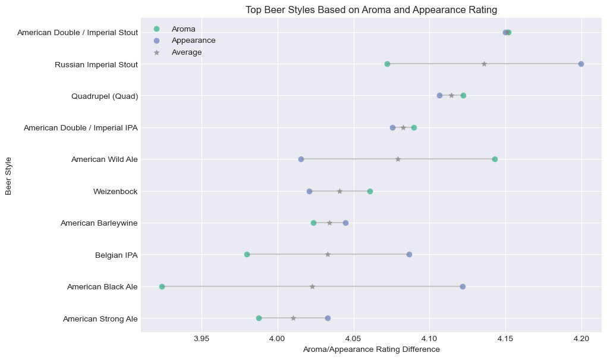

```python
### lolipop plot

# our data to plot
x0 = np.array(agg_style_sorted.review_aroma.head(10).iloc[::-1])
x1 = np.array(agg_style_sorted.review_appearance.head(10).iloc[::-1])
x2 = np.array(agg_style_sorted.aroma_appearance_mean.head(10).iloc[::-1])
y = agg_style_sorted.beer_style.head(10).iloc[::-1]

# since top 10
my_range = range(1,11)

# --- plot
x_min = np.minimum(x0, x1)
x_max = np.maximum(x0, x1)

plt.figure(figsize=(10,7), dpi= 100, facecolor='w', edgecolor='k')

plt.hlines(y=my_range, xmin=x_min, xmax=x_max, color='grey', alpha=0.4)
plt.scatter(x0, my_range, color= my_colors(0), label='Aroma')
plt.scatter(x1, my_range, color= my_colors(1), label='Appearance')
plt.scatter(x2, my_range, color= 'grey', alpha=0.6, marker='*', label='Average')
plt.legend(loc=2)

# --- title/axis
plt.yticks(my_range, y)
plt.title("Top Beer Styles Based on Aroma and Appearance Rating")
plt.xlabel('Aroma/Appearance Rating Difference')
plt.ylabel('Beer Style')


plt.show()
```

```python
agg_style_sorted = agg_style.sort_values('aro_app_weighted', ascending = False)
agg_style_sorted.head(10)
```

|  | beer_style | counts | review_overall | review_aroma | review_appearance | review_palate | review_taste | aroma_appearance_mean | aro_app_weighted |
| --- | --- | --- | --- | --- | --- | --- | --- | --- | --- |
| 11 | American Double / Imperial Stout | 40456 | 4.019070 | 4.152029 | 4.150040 | 4.093546 | 4.178577 | 4.151034 | 4.081411 |
| 89 | Russian Imperial Stout | 43173 | 4.014975 | 4.072059 | 4.199465 | 4.082030 | 4.138941 | 4.135762 | 4.072104 |
| 9 | American Double / Imperial IPA | 66973 | 3.986300 | 4.089700 | 4.075448 | 4.018336 | 4.077554 | 4.082574 | 4.044559 |
| 86 | Quadrupel (Quad) | 14865 | 4.057888 | 4.122032 | 4.106559 | 4.114497 | 4.196939 | 4.114295 | 3.976596 |
| 4 | American Barleywine | 21332 | 3.896540 | 4.023673 | 4.044604 | 4.004242 | 4.045729 | 4.034139 | 3.948022 |
| 20 | American Wild Ale | 13626 | 4.105423 | 4.142889 | 4.015375 | 4.056950 | 4.160906 | 4.079132 | 3.945611 |
| 19 | American Strong Ale | 25254 | 3.875980 | 3.987467 | 4.033005 | 3.964362 | 4.036212 | 4.010236 | 3.939865 |
| 25 | Belgian Strong Dark Ale | 30628 | 3.917837 | 3.981145 | 4.009387 | 3.946062 | 4.033940 | 3.995266 | 3.937749 |
| 12 | American IPA | 87940 | 3.967586 | 3.896452 | 3.978576 | 3.870571 | 3.918314 | 3.937514 | 3.919044 |
| 92 | Saison / Farmhouse Ale | 24247 | 3.967047 | 3.943807 | 4.018250 | 3.903844 | 3.938405 | 3.981029 | 3.915204 |

And here above are the top beer styles using my weighted review considering aroma and appearance, with the below plot contrasting aroma and appearance ratings for the top 10 beer styles using my weighted review.

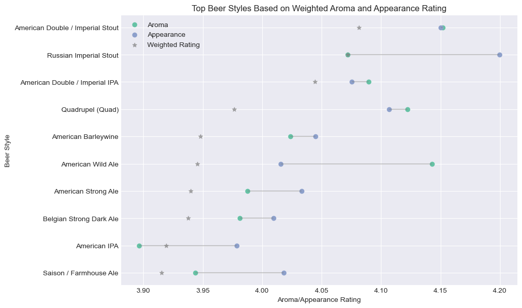

```python
### lolipop plot

# our data to plot
x0 = np.array(agg_style_sorted.review_aroma.head(10).iloc[::-1])
x1 = np.array(agg_style_sorted.review_appearance.head(10).iloc[::-1])
x2 = np.array(agg_style_sorted.aro_app_weighted.head(10).iloc[::-1])
y = agg_style_sorted.beer_style.head(10).iloc[::-1]

# since top 10
my_range = range(1,11)

# --- plot
x_min = np.minimum(x0, x1)
x_max = np.maximum(x0, x1)

plt.figure(figsize=(10,7), dpi= 100, facecolor='w', edgecolor='k')

plt.hlines(y=my_range, xmin=x_min, xmax=x_max, color='grey', alpha=0.4)
plt.scatter(x0, my_range, color= my_colors(0), label='Aroma')
plt.scatter(x1, my_range, color= my_colors(1), label='Appearance')
plt.scatter(x2, my_range, color= 'grey', alpha=0.6, marker='*', label='Weighted Rating')
plt.legend(loc=2)

# --- title/axis
plt.yticks(my_range, y)
plt.title("Top Beer Styles Based on Weighted Aroma and Appearance Rating")
plt.xlabel('Aroma/Appearance Rating')
plt.ylabel('Beer Style')


plt.show()
```